# Exportaciones Veritrade de minerales críticos (Latam)

### Boro (a EE.UU.)

Hacia Estados Unidos, **Boro** desde **Chile** suma 19 930,86 TM netas y USD 14,4 millones FOB (298 registros); eso es el **2,8%** del tonelaje de Boro exportado a todos los destinos; en **2025**: 2 305,12 TM y USD 2,0 millones (23 registros).

**Evolución anual hacia EE.UU.**

**Peso neto (TM)**

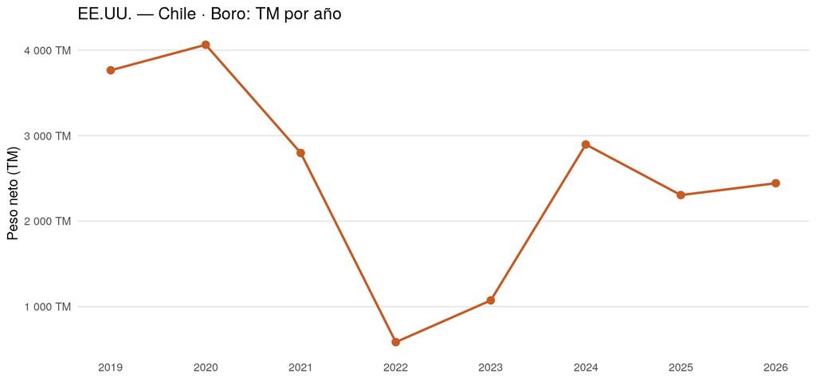

**FOB (USD)**

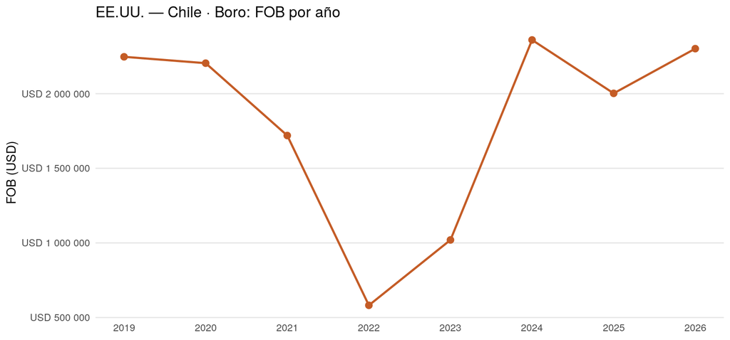

**Principales empresas exportadoras (destino EE.UU.)**

**Todo el periodo**

| Exportador | Peso neto | Porcentaje peso neto | FOB (USD) | Registros |
| --- | --- | --- | --- | --- |
| QUIBORAX S.A. | 19 490,50 TM | 97,8% | USD 14,0 millones | 294 |
| S Q M SALAR S A | 295,00 TM | 1,5% | USD 311 415 | 1 |
| Sin dato | 145,36 TM | 0,7% | USD 82 855 | 3 |

**2025**

| Exportador | Peso neto | Porcentaje peso neto | FOB (USD) | Registros |
| --- | --- | --- | --- | --- |
| QUIBORAX S.A. | 2 305,12 TM | 100,0% | USD 2,0 millones | 23 |

### Plomo (a EE.UU.)

Hacia Estados Unidos, **Plomo** desde **Chile** suma 1 276,75 TM netas y USD 2,4 millones FOB (7 registros); eso es el **1,4%** del tonelaje de Plomo exportado a todos los destinos.

**Evolución anual hacia EE.UU.**

**Peso neto (TM)**

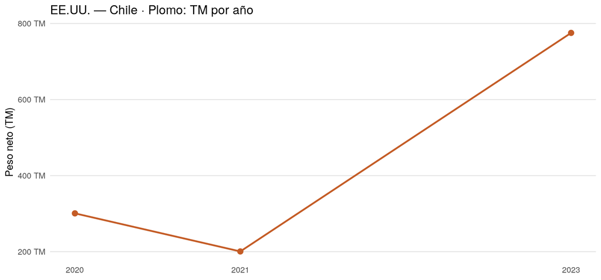

**FOB (USD)**

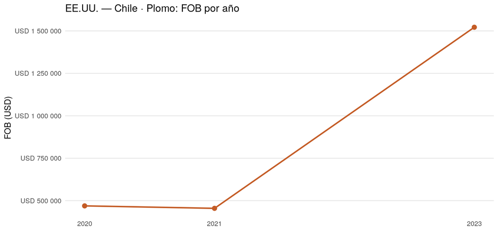

**Principales empresas exportadoras (destino EE.UU.)**

**Todo el periodo**

| Exportador | Peso neto | Porcentaje peso neto | FOB (USD) | Registros |
| --- | --- | --- | --- | --- |
| PROC.DE RESIDUOS INDUST. LTDA | 775,40 TM | 60,7% | USD 1,5 millones | 5 |
| Sin dato | 501,35 TM | 39,3% | USD 923 904 | 2 |

**2025**

| Exportador | Peso neto |
| --- | --- |
| — | — |

### Plata (a EE.UU.)

Hacia Estados Unidos, **Plata** desde **Chile** suma 1 197,61 TM netas y USD 1 133,2 millones FOB (878 registros); eso es el **75,1%** del tonelaje de Plata exportado a todos los destinos; en **2025**: 206,09 TM y USD 230,7 millones (170 registros).

**Evolución anual hacia EE.UU.**

**Peso neto (TM)**

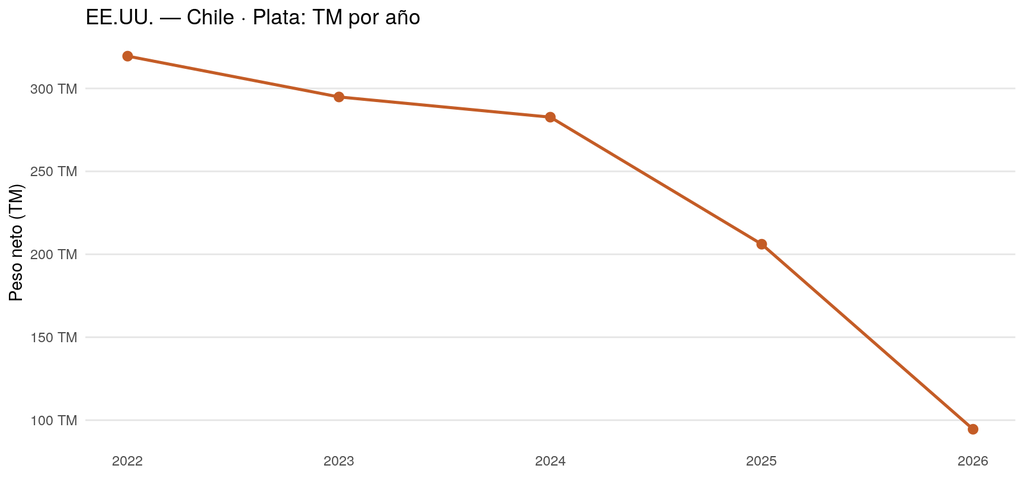

**FOB (USD)**

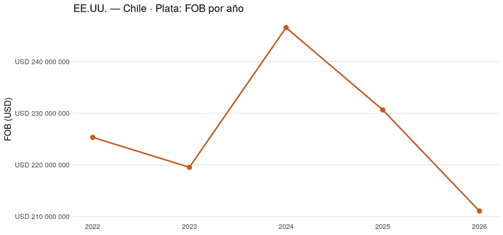

**Principales empresas exportadoras (destino EE.UU.)**

**Todo el periodo**

| Exportador | Peso neto | Porcentaje peso neto | FOB (USD) | Registros |
| --- | --- | --- | --- | --- |
| CORP NACIONAL DEL COBRE DE CHILE | 1 197,00 TM | 99,9% | USD 1 132,7 millones | 877 |
| ARGOR-HERAEUS LATIN AMERICA SPA | 0,61 TM | 0,1% | USD 531 765 | 1 |

**2025**

| Exportador | Peso neto | Porcentaje peso neto | FOB (USD) | Registros |
| --- | --- | --- | --- | --- |
| CORP NACIONAL DEL COBRE DE CHILE | 206,09 TM | 100,0% | USD 230,7 millones | 170 |

### Renio (a EE.UU.)

Hacia Estados Unidos, **Renio** desde **Chile** suma 82,00 TM netas y USD 159,3 millones FOB (140 registros); eso es el **94,9%** del tonelaje de Renio exportado a todos los destinos; en **2025**: 27,16 TM y USD 54,1 millones (54 registros).

**Evolución anual hacia EE.UU.**

**Peso neto (TM)**

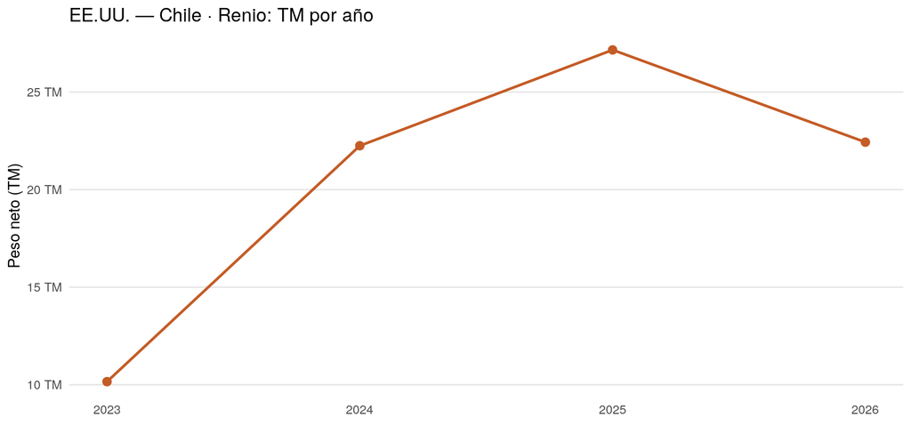

**FOB (USD)**

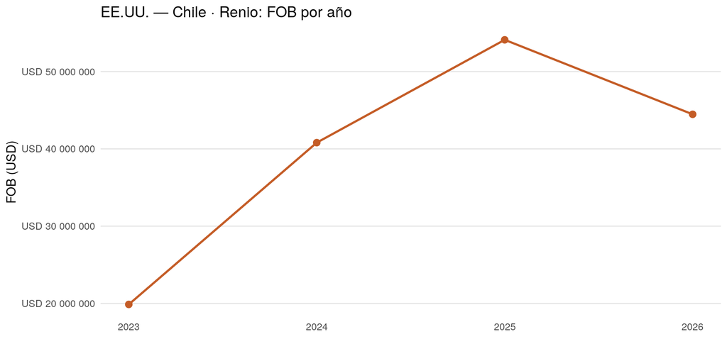

**Principales empresas exportadoras (destino EE.UU.)**

**Todo el periodo**

| Exportador | Peso neto | Porcentaje peso neto | FOB (USD) | Registros |
| --- | --- | --- | --- | --- |
| MOLIBDENOS Y METALES S A | 80,80 TM | 98,5% | USD 157,6 millones | 128 |
| CORP NACIONAL DEL COBRE DE CHILE | 1,20 TM | 1,5% | USD 1,7 millones | 12 |

**2025**

| Exportador | Peso neto | Porcentaje peso neto | FOB (USD) | Registros |
| --- | --- | --- | --- | --- |
| MOLIBDENOS Y METALES S A | 26,26 TM | 96,7% | USD 52,9 millones | 45 |
| CORP NACIONAL DEL COBRE DE CHILE | 0,90 TM | 3,3% | USD 1,3 millones | 9 |

## A EE.UU. · Colombia

En la tabla, **Porcentaje peso neto** es la participación de cada mineral en el tonelaje de este país hacia EE.UU. **Porcentaje de todo exportado** (columna sombreada) es el peso neto (TM) enviado a EE.UU. de ese mineral dividido entre el peso neto del mismo mineral exportado a **todos** los destinos en el scrape. Ejemplo: si Perú exporta 412 396 TM de cobre a EE.UU., la columna sombreada dice qué fracción son de todo el cobre peruano exportado (todos los países).

| Mineral | Peso neto | Porcentaje peso neto | FOB (USD) | Porcentaje de todo exportado | Registros |
| --- | --- | --- | --- | --- | --- |
| Níquel | 25 787,87 TM | 84,5% | USD 118,2 millones | 2,5% | 88 |
| Cobre | 4 690,81 TM | 15,4% | USD 26,9 millones | 0,7% | 283 |
| Plata | 42,59 TM | 0,1% | USD 46,1 millones | 2,2% | 198 |
| Platino | 3,07 TM | 0,0% | USD 94,2 millones | 46,2% | 327 |

### Níquel (a EE.UU.)

Hacia Estados Unidos, **Níquel** desde **Colombia** suma 25 787,87 TM netas y USD 118,2 millones FOB (88 registros); eso es el **2,5%** del tonelaje de Níquel exportado a todos los destinos; en **2025**: 4 498,77 TM y USD 16,1 millones (15 registros).

**Evolución anual hacia EE.UU.**

**Peso neto (TM)**

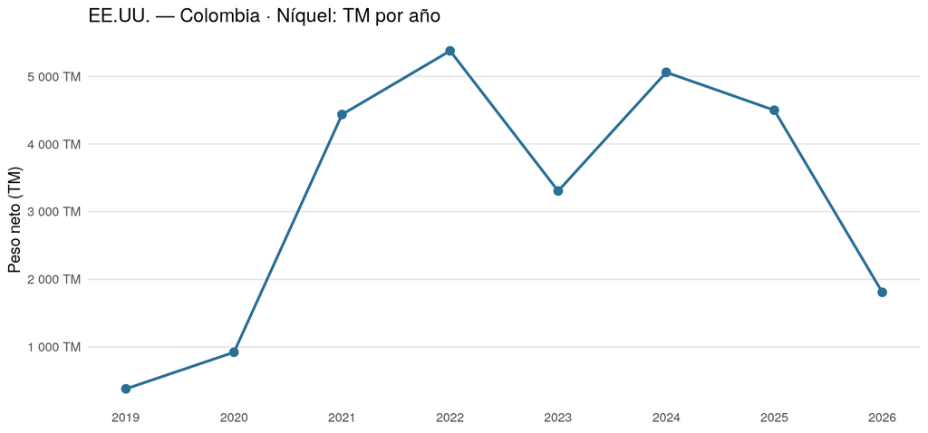

**FOB (USD)**

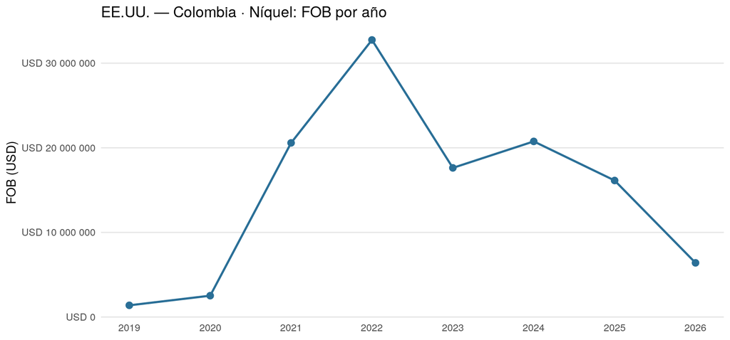

**Principales empresas exportadoras (destino EE.UU.)**

**Todo el periodo**

| Exportador | Peso neto | Porcentaje peso neto | FOB (USD) | Registros |
| --- | --- | --- | --- | --- |
| CERRO MATOSO SA | 25 762,80 TM | 99,9% | USD 118,0 millones | 86 |
| MOLDES MEDELLIN LTDA | 13,72 TM | 0,1% | USD 131 559 | 1 |
| C I ACA ALUMINIOS COBRES Y ACEROS S A S | 11,34 TM | 0,0% | USD 55 221 | 1 |

**2025**

| Exportador | Peso neto | Porcentaje peso neto | FOB (USD) | Registros |
| --- | --- | --- | --- | --- |
| CERRO MATOSO SA | 4 498,77 TM | 100,0% | USD 16,1 millones | 15 |

### Cobre (a EE.UU.)

Hacia Estados Unidos, **Cobre** desde **Colombia** suma 4 690,81 TM netas y USD 26,9 millones FOB (283 registros); eso es el **0,7%** del tonelaje de Cobre exportado a todos los destinos; en **2025**: 201,54 TM y USD 1,3 millones (11 registros).

**Evolución anual hacia EE.UU.**

**Peso neto (TM)**

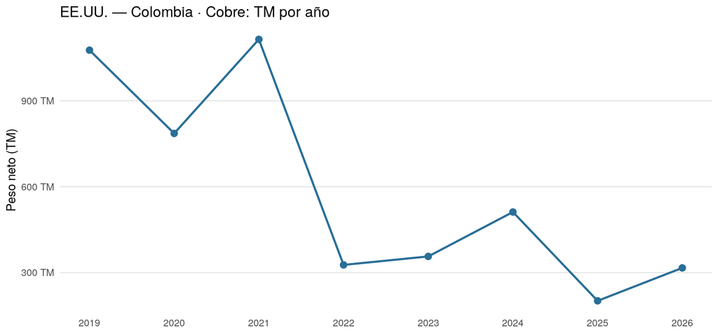

**FOB (USD)**

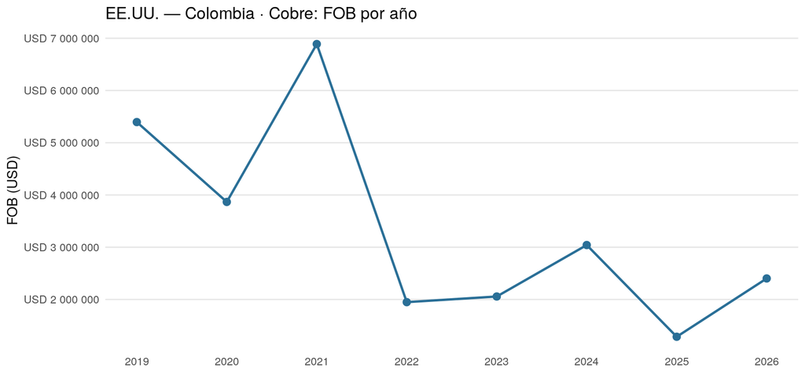

**Principales empresas exportadoras (destino EE.UU.)**

**Todo el periodo**

| Exportador | Peso neto | Porcentaje peso neto | FOB (USD) | Registros |
| --- | --- | --- | --- | --- |
| PRODUCTORA DE CABLES PROCABLES SAS | 1 339,97 TM | 28,6% | USD 7,8 millones | 74 |
| C I METALES LA UNION S A S | 723,26 TM | 15,4% | USD 4,6 millones | 28 |
| ATLANTICMETALS S A S | 537,26 TM | 11,5% | USD 2,6 millones | 37 |
| C I ACA ALUMINIOS COBRES Y ACEROS S A S | 446,91 TM | 9,5% | USD 2,3 millones | 25 |
| C.I PRIME METALS S.A.S | 391,62 TM | 8,3% | USD 2,5 millones | 32 |
| FLEXONSILCA S A | 289,41 TM | 6,2% | USD 1,1 millones | 16 |
| CI INNOAMBIENTAL SAS | 251,96 TM | 5,4% | USD 1,8 millones | 22 |
| SOC DE COMERCIALIZACION INTL RECYCABLES S A S | 137,20 TM | 2,9% | USD 705 781 | 9 |
| CI ECOLOMBIA EXPORT S.A.S | 130,74 TM | 2,8% | USD 772 357 | 11 |
| MACROMETALES SAS | 114,86 TM | 2,4% | USD 950 530 | 5 |

**2025**

| Exportador | Peso neto | Porcentaje peso neto | FOB (USD) | Registros |
| --- | --- | --- | --- | --- |
| PRODUCTORA DE CABLES PROCABLES SAS | 176,54 TM | 87,6% | USD 1,2 millones | 7 |
| C I ACA ALUMINIOS COBRES Y ACEROS S A S | 24,68 TM | 12,2% | USD 52 469 | 1 |
| PERSONA NATURAL | 0,26 TM | 0,1% | USD 122 | 1 |
| TECNOAPLICACIONES S A S | 0,06 TM | 0,0% | USD 19 | 1 |
| FRESH PRODUCTS Y LOGISTICS S A S | 0,01 TM | 0,0% | USD 90 | 1 |

### Plata (a EE.UU.)

Hacia Estados Unidos, **Plata** desde **Colombia** suma 42,59 TM netas y USD 46,1 millones FOB (198 registros); eso es el **2,2%** del tonelaje de Plata exportado a todos los destinos; en **2025**: 7,64 TM y USD 8,8 millones (41 registros).

**Evolución anual hacia EE.UU.**

**Peso neto (TM)**

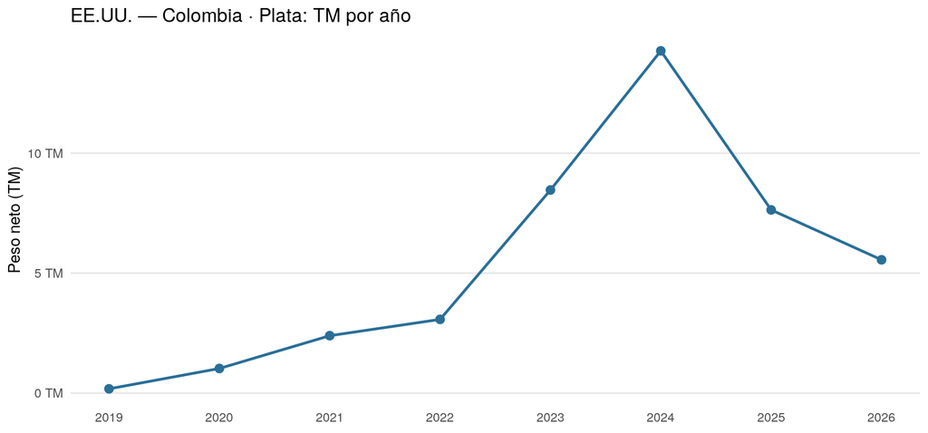

**FOB (USD)**

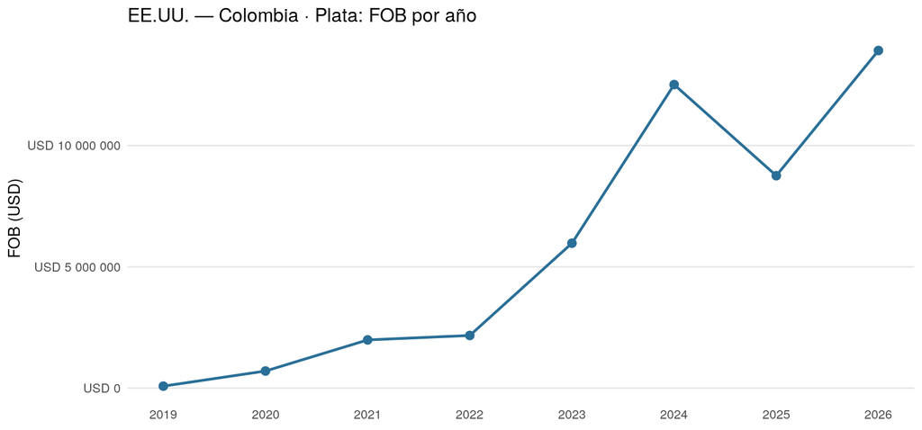

**Principales empresas exportadoras (destino EE.UU.)**

**Todo el periodo**

| Exportador | Peso neto | Porcentaje peso neto | FOB (USD) | Registros |
| --- | --- | --- | --- | --- |
| LATRANS GRUPO LOGISTICO S A S | 35,11 TM | 82,4% | USD 39,9 millones | 125 |
| CIALZ INT DE MET PRECIOSOS Y MET COMUNES INV GENERALES S A | 3,67 TM | 8,6% | USD 2,6 millones | 13 |
| UNIVERSAL MINERALS S A S | 1,47 TM | 3,4% | USD 1,2 millones | 8 |
| YS METALES Y JOYAS S A S | 0,46 TM | 1,1% | USD 317 704 | 7 |
| C. I. PROMOTORA MINERA GLOBAL SAS | 0,36 TM | 0,8% | USD 653 238 | 4 |
| ALMATRAS SAS | 0,28 TM | 0,7% | USD 219 905 | 3 |
| NAPLES PRIME S A S C I | 0,23 TM | 0,5% | USD 187 328 | 2 |
| TECNOGLASS S A | 0,20 TM | 0,5% | USD 406 452 | 1 |
| C I GRUPO EXPORTADOR SAS | 0,15 TM | 0,4% | USD 151 793 | 1 |
| CI VOLKOU S.A.S | 0,10 TM | 0,2% | USD 141 352 | 8 |

**2025**

| Exportador | Peso neto | Porcentaje peso neto | FOB (USD) | Registros |
| --- | --- | --- | --- | --- |
| LATRANS GRUPO LOGISTICO S A S | 6,94 TM | 90,9% | USD 8,1 millones | 30 |
| CIALZ INT DE MET PRECIOSOS Y MET COMUNES INV GENERALES S A | 0,51 TM | 6,7% | USD 459 875 | 3 |
| C I GRUPO EXPORTADOR SAS | 0,15 TM | 2,0% | USD 151 793 | 1 |
| CI VOLKOU S.A.S | 0,04 TM | 0,5% | USD 46 571 | 4 |
| GRUBER SAS | 0,00 TM | 0,0% | USD 534 | 1 |
| ALLOY S A S | 0,00 TM | 0,0% | USD 1 200 | 2 |

### Platino (a EE.UU.)

Hacia Estados Unidos, **Platino** desde **Colombia** suma 3,07 TM netas y USD 94,2 millones FOB (327 registros); eso es el **46,2%** del tonelaje de Platino exportado a todos los destinos; en **2025**: 0,59 TM y USD 21,7 millones (59 registros).

**Evolución anual hacia EE.UU.**

**Peso neto (TM)**

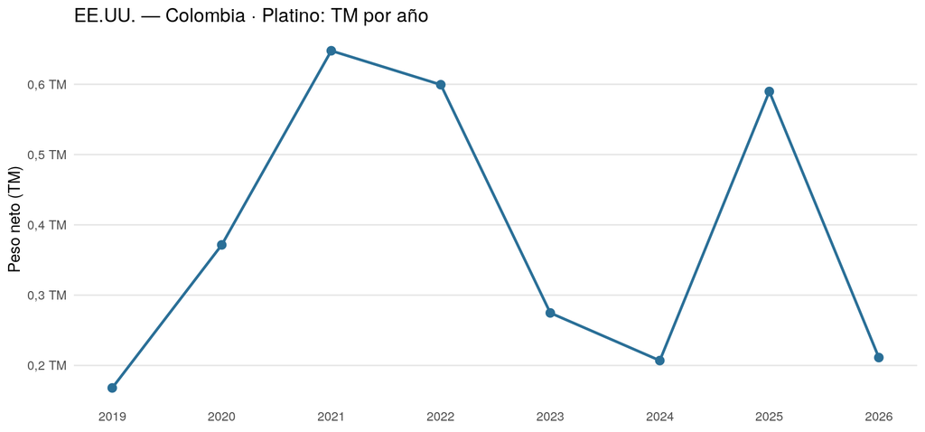

**FOB (USD)**

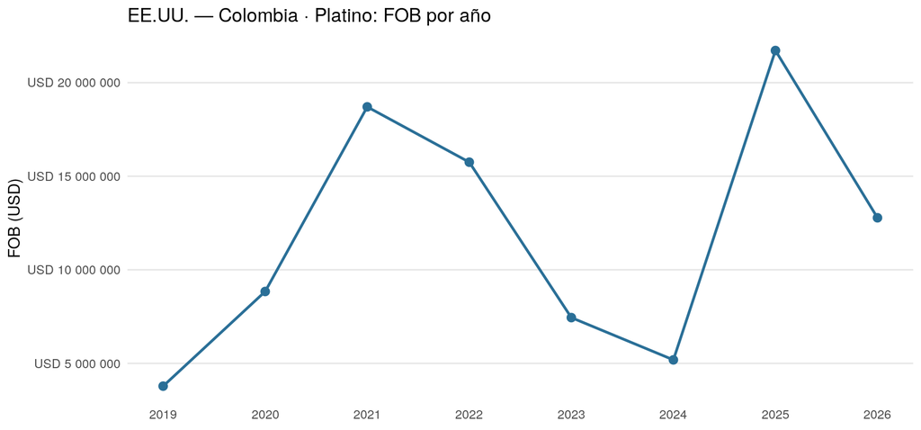

**Principales empresas exportadoras (destino EE.UU.)**

**Todo el periodo**

| Exportador | Peso neto | Porcentaje peso neto | FOB (USD) | Registros |
| --- | --- | --- | --- | --- |
| SUMITRADE SAS | 1,10 TM | 36,0% | USD 29,8 millones | 55 |
| COMERCIALIZADORA INTL ESLOP S A S | 0,63 TM | 20,5% | USD 27,5 millones | 36 |
| SOC DE COMERCIALIZACION INTL ANTIOQUENA DE EXP | 0,42 TM | 13,6% | USD 11,6 millones | 31 |
| C I DE METALES PRECIOSOS DE COLOMBIA S A | 0,16 TM | 5,2% | USD 3,8 millones | 19 |
| C.I ARANY S.A.S. | 0,10 TM | 3,4% | USD 3,8 millones | 17 |
| COMERCIALIZADORA INTERNACIONAL COLTIC SAS | 0,08 TM | 2,7% | USD 2,2 millones | 29 |
| CARBONTERRA MINERAL SAS | 0,07 TM | 2,4% | USD 1,7 millones | 14 |
| CONSULTORIAS ME INGENIERIA S A S | 0,06 TM | 1,8% | USD 1,6 millones | 9 |
| IINTI MINING GROUP S A S | 0,05 TM | 1,6% | USD 1,1 millones | 14 |
| C I GRUPO EXPORTADOR SAS | 0,04 TM | 1,2% | USD 1,4 millones | 4 |

**2025**

| Exportador | Peso neto | Porcentaje peso neto | FOB (USD) | Registros |
| --- | --- | --- | --- | --- |
| COMERCIALIZADORA INTL ESLOP S A S | 0,44 TM | 74,6% | USD 16,7 millones | 19 |
| C.I ARANY S.A.S. | 0,09 TM | 15,0% | USD 3,0 millones | 14 |
| COMERCIALIZADORA INTERNACIONAL COLTIC SAS | 0,02 TM | 3,7% | USD 602 003 | 10 |
| C I GRUPO EXPORTADOR SAS | 0,01 TM | 1,9% | USD 401 981 | 1 |
| NEGOCIOS F Y M METALES S.A.S | 0,01 TM | 1,9% | USD 436 147 | 3 |
| GRUBER SAS | 0,01 TM | 1,3% | USD 291 147 | 7 |
| CI GS LOGISTIC SAS | 0,01 TM | 0,9% | USD 207 909 | 2 |
| C I GLOBAL MULTI COMMODITIES SAS | 0,00 TM | 0,5% | USD 73 056 | 1 |
| CMGOLD SAS | 0,00 TM | 0,2% | USD 51 734 | 1 |
| C. I. PROMOTORA MINERA GLOBAL SAS | 0,00 TM | 0,1% | USD 14 879 | 1 |

## A EE.UU. · Ecuador

En la tabla, **Porcentaje peso neto** es la participación de cada mineral en el tonelaje de este país hacia EE.UU. **Porcentaje de todo exportado** (columna sombreada) es el peso neto (TM) enviado a EE.UU. de ese mineral dividido entre el peso neto del mismo mineral exportado a **todos** los destinos en el scrape. Ejemplo: si Perú exporta 412 396 TM de cobre a EE.UU., la columna sombreada dice qué fracción son de todo el cobre peruano exportado (todos los países).

| Mineral | Peso neto | Porcentaje peso neto | FOB (USD) | Porcentaje de todo exportado | Registros |
| --- | --- | --- | --- | --- | --- |
| Cobre | 2 225,47 TM | 99,7% | USD 14,3 millones | 0,1% | 283 |
| Plata | 6,10 TM | 0,3% | USD 3,2 millones | 0,5% | 50 |

### Cobre (a EE.UU.)

Hacia Estados Unidos, **Cobre** desde **Ecuador** suma 2 225,47 TM netas y USD 14,3 millones FOB (283 registros); eso es el **0,1%** del tonelaje de Cobre exportado a todos los destinos; en **2025**: 177,60 TM y USD 1,2 millones (27 registros).

**Evolución anual hacia EE.UU.**

**Peso neto (TM)**

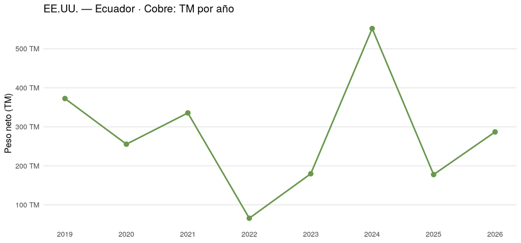

**FOB (USD)**

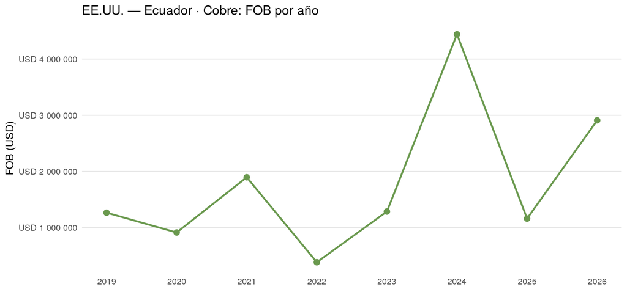

**Principales empresas exportadoras (destino EE.UU.)**

**Todo el periodo**

| Exportador | Peso neto | Porcentaje peso neto | FOB (USD) | Registros |
| --- | --- | --- | --- | --- |
| METALKING S.A. | 1 340,96 TM | 60,3% | USD 8,9 millones | 164 |
| ACERIA DEL ECUADOR CA ADELCA. | 235,00 TM | 10,6% | USD 1,2 millones | 18 |
| PRACTIPOWER S.A. | 208,69 TM | 9,4% | USD 1,5 millones | 14 |
| ECUAPETSA PET DEL ECUADOR S.A. | 175,72 TM | 7,9% | USD 1,6 millones | 31 |
| COBRE PREMIUM | 79,64 TM | 3,6% | USD 505 474 | 38 |
| FUNDAMETZ S.A. | 75,00 TM | 3,4% | USD 251 615 | 5 |
| CONSULTORA VERTMONDE S.A.S. B.I.C. | 54,93 TM | 2,5% | USD 49 917 | 4 |
| ECORESA ECOLOGIA & RECICLAJE S.A. | 39,50 TM | 1,8% | USD 189 952 | 2 |
| SSING PLASTIC S.A.S. | 10,00 TM | 0,4% | USD 50 000 | 1 |
| COBRE PREMIUM CIA LTDA | 5,58 TM | 0,3% | USD 27 545 | 4 |

**2025**

| Exportador | Peso neto | Porcentaje peso neto | FOB (USD) | Registros |
| --- | --- | --- | --- | --- |
| METALKING S.A. | 79,63 TM | 44,8% | USD 514 868 | 15 |
| ACERIA DEL ECUADOR CA ADELCA. | 77,38 TM | 43,6% | USD 528 000 | 8 |
| PRACTIPOWER S.A. | 19,54 TM | 11,0% | USD 113 930 | 2 |
| ECUAPETSA PET DEL ECUADOR S.A. | 1,05 TM | 0,6% | USD 5 345 | 2 |

### Plata (a EE.UU.)

Hacia Estados Unidos, **Plata** desde **Ecuador** suma 6,10 TM netas y USD 3,2 millones FOB (50 registros); eso es el **0,5%** del tonelaje de Plata exportado a todos los destinos; en **2025**: 0,78 TM y USD 740 702 (7 registros).

**Evolución anual hacia EE.UU.**

**Peso neto (TM)**

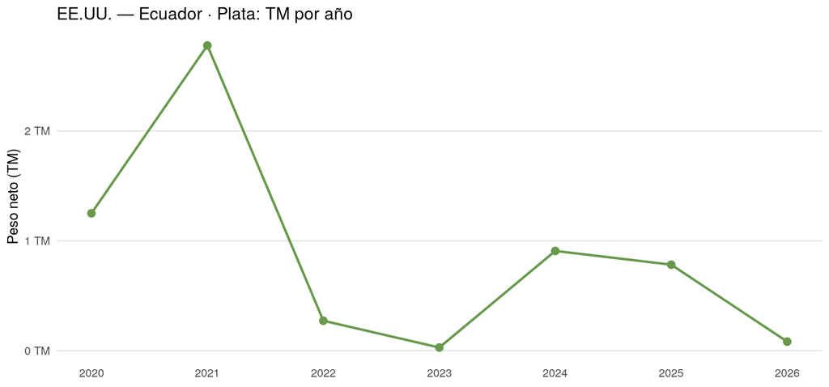

**FOB (USD)**

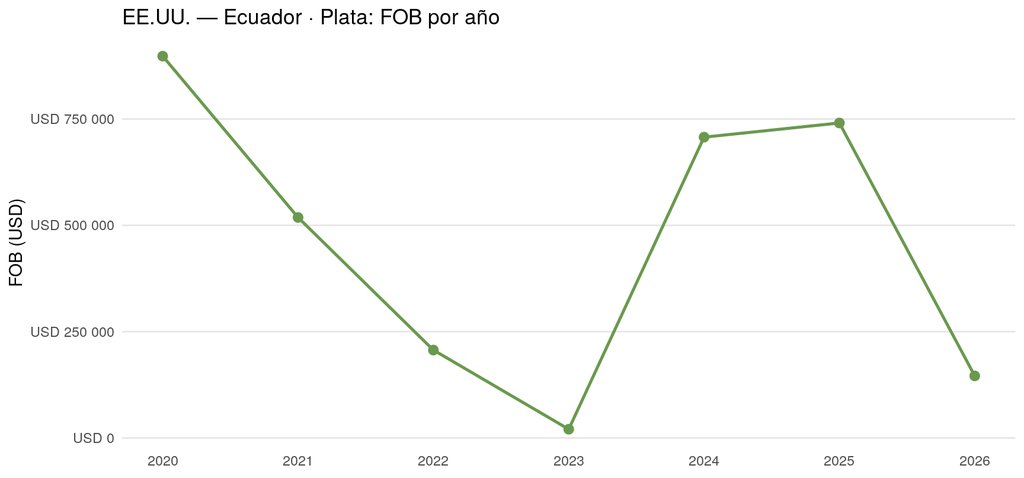

**Principales empresas exportadoras (destino EE.UU.)**

**Todo el periodo**

| Exportador | Peso neto | Porcentaje peso neto | FOB (USD) | Registros |
| --- | --- | --- | --- | --- |
| ROMERO LEON EDWIN IVAN | 1,07 TM | 17,6% | USD 933 463 | 10 |
| MARTINEZ LOAIZA DANIEL ALBERTO | 0,45 TM | 7,5% | USD 348 156 | 7 |
| OROCORMINA CIA LTDA | 0,39 TM | 6,3% | USD 273 514 | 2 |
| SOCIEDAD MINERA LIGA DE ORO S A SOMILOR | 0,36 TM | 5,8% | USD 278 736 | 2 |
| CORPORACION MINERA MIRANDA MINERMIR S A | 0,35 TM | 5,7% | USD 268 383 | 3 |
| OROCONCENT S A | 0,30 TM | 4,9% | USD 192 189 | 2 |
| MORA AGUILAR LUIS FERNANDO | 0,23 TM | 3,7% | USD 170 048 | 2 |
| METAL CORP S&T S.A. | 0,19 TM | 3,2% | USD 265 101 | 2 |
| BURSAL S A | 0,14 TM | 2,2% | USD 107 594 | 2 |
| NUMINEC S.A. | 0,12 TM | 2,0% | USD 89 637 | 2 |

**2025**

| Exportador | Peso neto | Porcentaje peso neto | FOB (USD) | Registros |
| --- | --- | --- | --- | --- |
| ROMERO LEON EDWIN IVAN | 0,67 TM | 85,7% | USD 621 463 | 6 |
| METAL CORP S&T S.A. | 0,11 TM | 14,3% | USD 119 238 | 1 |

# Fuentes

- Sheet [Críticos Latam × partidas](https://docs.google.com/spreadsheets/d/1Y181GDonjbUTv3DuH-1dfBxMP2oRGGL6yU8NrS81UbM/edit) — universo de partidas del scrape.
- Veritrade (exportaciones): `data/veritrade/<pais>/` → `analisis/staging_veritrade_exports/` (`ingest_veritrade_exports.py`). Destino EE.UU. = glosa `ESTADOS UNIDOS`.
- Memo: [`memo-minerales-criticos-latam`](https://docs.google.com/document/d/1gvR_om7BNTnqSQjOsRDc96x94YKmpAuWr6IyKfFRq_4/edit).